# HW3

Recep Talha Bölükbaş

28 05 2021

# Hourly Electric Consumption

Required libraries are listed below.

```r
library(data.table)
```

```r
library(ggplot2)
library(stringr)
require(lubridate)
require(zoo)
require(forecast)
require(stats)
```

## Data Reading and Manipulations

First of all we need to read the data and change it to an appropriate class type.I convert mydata to a data table to work on it easily.

```r
mydata=read.csv("/Users/rtbol/Desktop/GercekZamanliTuketim.csv")
elec_consumption = data.table(mydata)
str(elec_consumption)
```

```
## Classes 'data.table' and 'data.frame':   47208 obs. of  3 variables:
##  $ Tarih                : chr  "01.01.2016" "01.01.2016" "01.01.2016" "01.01.2016" ...
##  $ Saat                 : chr  "00:00" "01:00" "02:00" "03:00" ...
##  $ Tüketim.Miktarı..MWh.: chr  "26.277,24" "24.991,82" "23.532,61" "22.464,78" ...
##  - attr(*, ".internal.selfref")=<externalptr>
```

```r
is.data.table(elec_consumption)
```

```
## [1] TRUE
```

```r
elec_consumption
```

```
##             Tarih  Saat Tüketim.Miktarı..MWh.
##     1: 01.01.2016 00:00             26.277,24
##     2: 01.01.2016 01:00             24.991,82
##     3: 01.01.2016 02:00             23.532,61
##     4: 01.01.2016 03:00             22.464,78
##     5: 01.01.2016 04:00             22.002,91
##    ---
## 47204: 20.05.2021 19:00             37.793,51
## 47205: 20.05.2021 20:00             38.805,79
## 47206: 20.05.2021 21:00             38.413,45
## 47207: 20.05.2021 22:00             37.630,77
## 47208: 20.05.2021 23:00             36.126,55
```

To continue I need to make some manipulation on data such as preparing appropriate Date and changing Tüketim.Miktarı..Mwh. from char to num. There are 3 important changes to create proper date values. datewtime is my last column with full date and hours of day.

```r
change = str_remove(elec_consumption$Tüketim.Miktarı..MWh., "[.]")
elec_consumption[,Consumption:=change]
change2 = gsub(",", ".",elec_consumption$Consumption)
elec_consumption[,Consumption:=change2]
elec_consumption$Consumption = as.numeric(elec_consumption$Consumption)
class(elec_consumption$Consumption)
```

```
## [1] "numeric"
```

```r
change3 = gsub(":", ".", elec_consumption$Saat)
elec_consumption[,Hours:=change3]
elec_consumption$Hours = as.numeric(elec_consumption$Hours)
elec_consumption[,Date:=as.Date(elec_consumption$Tarih,format="%d.%m.%Y")]
elec_consumption[,datewtime:=ymd(Date)+dhours(Hours)]
elec_consumption
```

```
##             Tarih  Saat Tüketim.Miktarı..MWh. Consumption Hours       Date
##     1: 01.01.2016 00:00             26.277,24    26277.24     0 2016-01-01
##     2: 01.01.2016 01:00             24.991,82    24991.82     1 2016-01-01
##     3: 01.01.2016 02:00             23.532,61    23532.61     2 2016-01-01
##     4: 01.01.2016 03:00             22.464,78    22464.78     3 2016-01-01
##     5: 01.01.2016 04:00             22.002,91    22002.91     4 2016-01-01
##    ---
## 47204: 20.05.2021 19:00             37.793,51    37793.51    19 2021-05-20
## 47205: 20.05.2021 20:00             38.805,79    38805.79    20 2021-05-20
## 47206: 20.05.2021 21:00             38.413,45    38413.45    21 2021-05-20
## 47207: 20.05.2021 22:00             37.630,77    37630.77    22 2021-05-20
## 47208: 20.05.2021 23:00             36.126,55    36126.55    23 2021-05-20
##                  datewtime
##     1: 2016-01-01 00:00:00
##     2: 2016-01-01 01:00:00
##     3: 2016-01-01 02:00:00
##     4: 2016-01-01 03:00:00
##     5: 2016-01-01 04:00:00
##    ---
## 47204: 2021-05-20 19:00:00
## 47205: 2021-05-20 20:00:00
## 47206: 2021-05-20 21:00:00
## 47207: 2021-05-20 22:00:00
## 47208: 2021-05-20 23:00:00
```

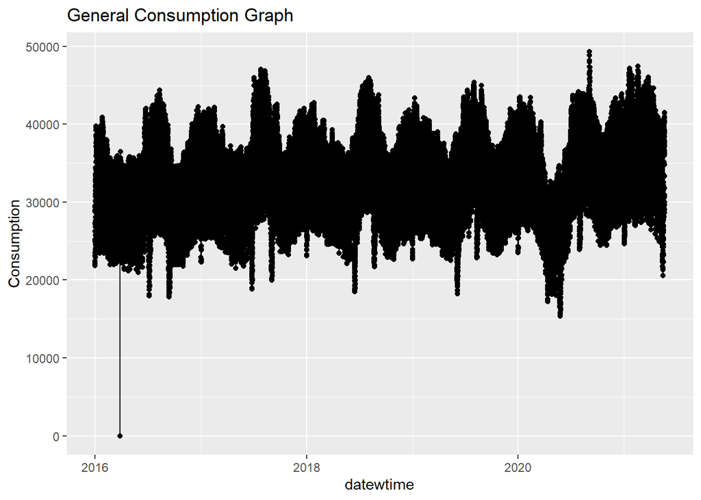

```r
ggplot(elec_consumption, aes(x=datewtime, y=Consumption)) + geom_line() + geom_point() + ggtitle("General Consumption Graph")
```

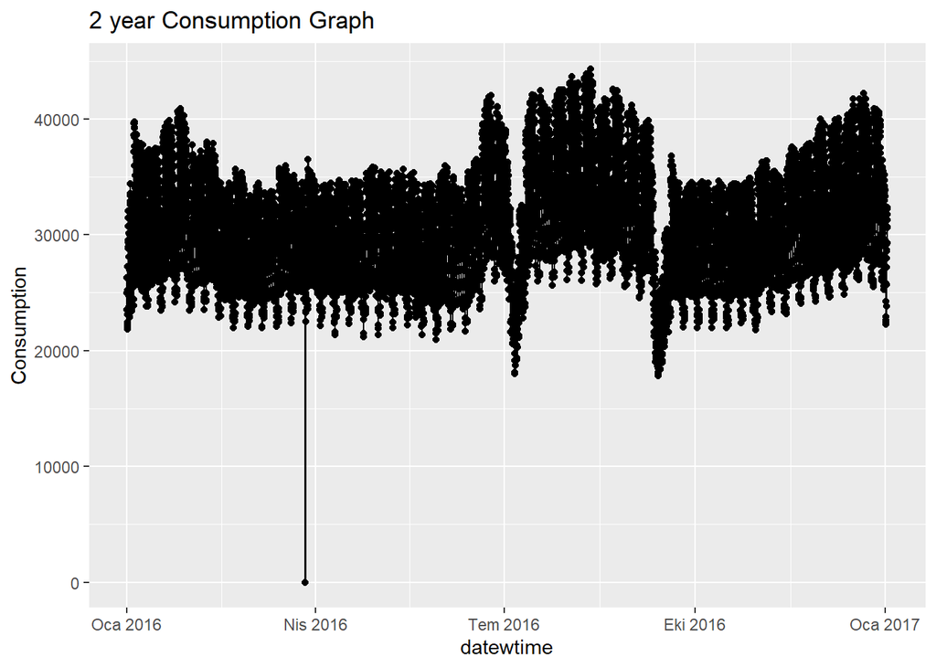

```r
ggplot(elec_consumption[Date>="2016-01-01" & Date<="2017-01-01"], aes(x=datewtime, y=Consumption)) + geom_line() + geom_point() + ggtitle("2 year Consumption Graph")
```

```r
elec_consumption[Date>="2016-03-01" & Date <="2016-03-31"]
```

```
##           Tarih  Saat Tüketim.Miktarı..MWh. Consumption Hours       Date
##   1: 01.03.2016 00:00             27.186,07    27186.07     0 2016-03-01
##   2: 01.03.2016 01:00             25.679,76    25679.76     1 2016-03-01
##   3: 01.03.2016 02:00             24.743,83    24743.83     2 2016-03-01
##   4: 01.03.2016 03:00             24.405,31    24405.31     3 2016-03-01
##   5: 01.03.2016 04:00             24.226,34    24226.34     4 2016-03-01
##  ---
## 740: 31.03.2016 19:00             32.799,41    32799.41    19 2016-03-31
## 741: 31.03.2016 20:00             33.286,27    33286.27    20 2016-03-31
## 742: 31.03.2016 21:00             32.591,64    32591.64    21 2016-03-31
## 743: 31.03.2016 22:00             32.641,06    32641.06    22 2016-03-31
## 744: 31.03.2016 23:00             30.953,79    30953.79    23 2016-03-31
##                datewtime
##   1: 2016-03-01 00:00:00
##   2: 2016-03-01 01:00:00
##   3: 2016-03-01 02:00:00
##   4: 2016-03-01 03:00:00
##   5: 2016-03-01 04:00:00
##  ---
## 740: 2016-03-31 19:00:00
## 741: 2016-03-31 20:00:00
## 742: 2016-03-31 21:00:00
## 743: 2016-03-31 22:00:00
## 744: 2016-03-31 23:00:00
```

I need to change consumption value in 2016-03-27 02:00, since it is 0 it may lead me to make wrong analyzes.I decided to take average of all other values in 2016-03-27 and send it to 02:00. By that way, I will get rid of one big outlier. Then I checked the graph again.

```r
avg = sum(elec_consumption[Date=="2016-03-27",Consumption])/23
elec_consumption[Date == "2016-03-27" & Saat == "02:00",Consumption := avg]
elec_consumption[Date == "2016-03-27" & Saat == "02:00"]
```

```
##         Tarih  Saat Tüketim.Miktarı..MWh. Consumption Hours       Date
## 1: 27.03.2016 02:00                  0,00    27213.79     2 2016-03-27
##              datewtime
## 1: 2016-03-27 02:00:00
```

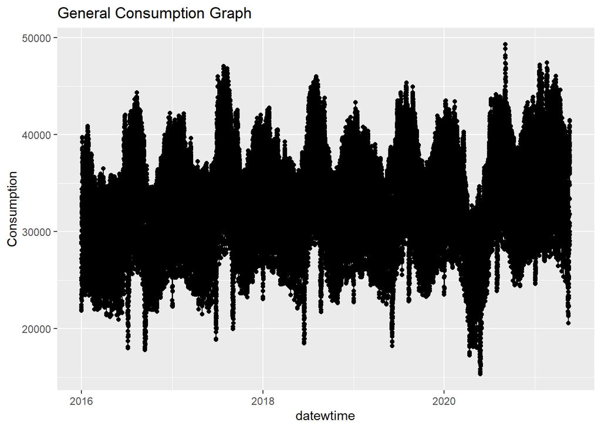

```r
ggplot(elec_consumption, aes(x=datewtime, y=Consumption)) + geom_line() + geom_point() + ggtitle("General Consumption Graph")
```

In our data it is possible to see some seasonality and trend. Especially sometimes consumption values decreased to deep values. To determine type of this seasonality beginning from hourly seasonality, I will try some seasonalities to my data and decompose data based on these seasonalities.

## Decomposition of Data at Different Levels

My first series will be hourly time series and I will check if there is an hourly seasonality or not.

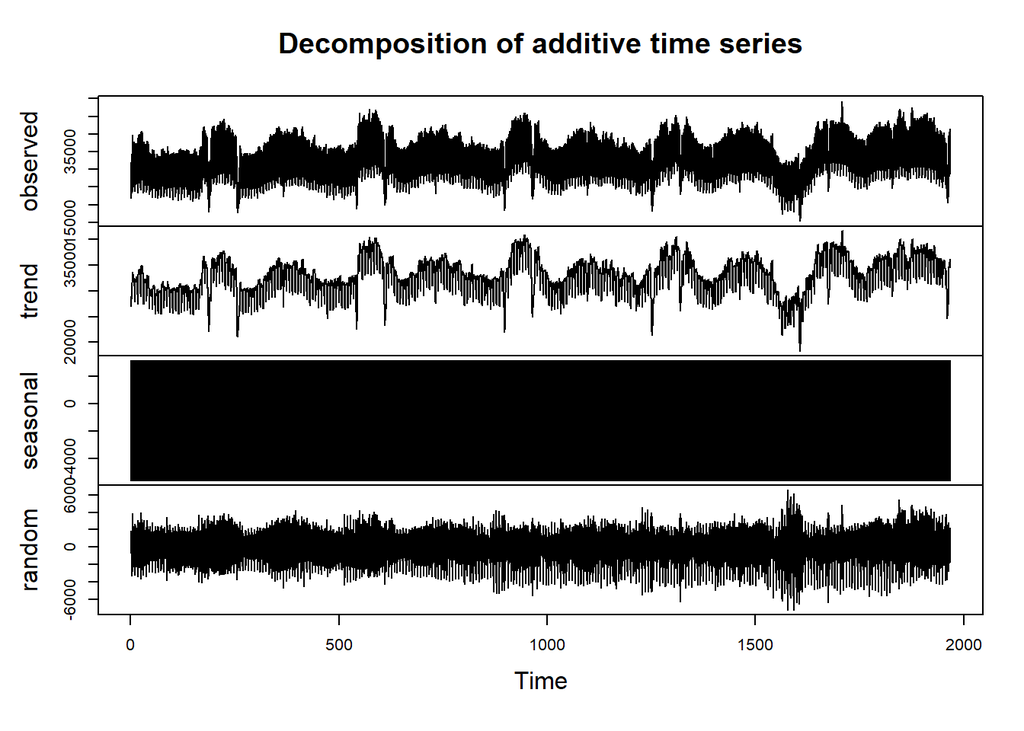

```r
ts_consumption_hourly = ts(elec_consumption$Consumption, freq = 24)
dec_ts = decompose(ts_consumption_hourly, type="additive")
plot(dec_ts)
```

In decomposition graph of hourly seasonality model, our graphs are really hard to make comments on it. All I can say that there is sometimes increasing sometimes decreasing trend graph and random part of decomposition mostly follows 0 mean and equal variance with some exceptional at the end of the data (most probably because of pandemic constraints in Turkey).

Next, I will look at the daily consumption values and I will plot 2 weeks daily consumption values between March 7th and March 21st. I tried to choose date interval without any holiday except weekends.

```r
daily_cons = elec_consumption[,list(total_cons = sum(Consumption,na.rm=T)),by=list(Date)]
daily_cons
```

```
##             Date total_cons
##    1: 2016-01-01   648689.2
##    2: 2016-01-02   702608.5
##    3: 2016-01-03   685453.1
##    4: 2016-01-04   794904.7
##    5: 2016-01-05   796749.9
##   ---
## 1963: 2021-05-16   677635.7
## 1964: 2021-05-17   811242.1
## 1965: 2021-05-18   855112.9
## 1966: 2021-05-19   829748.2
## 1967: 2021-05-20   870574.4
```

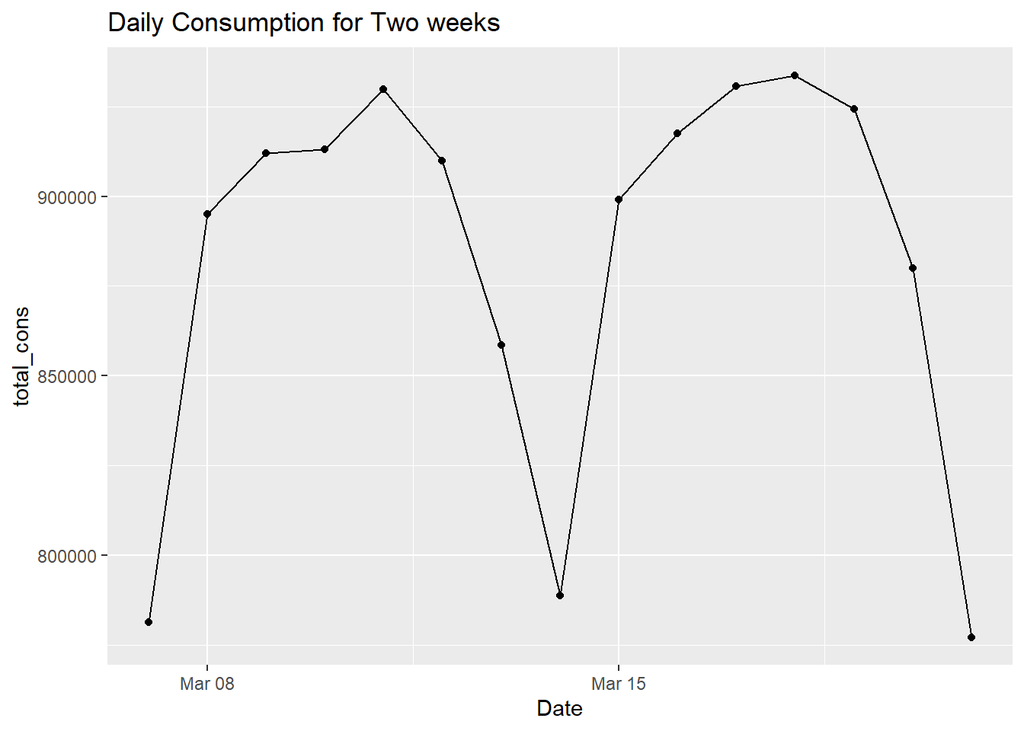

```r
ggplot(daily_cons[Date<='2021-03-21' & Date>='2021-03-07'], aes(x=Date,y=total_cons)) + geom_line() + geom_point() + ggtitle("Daily Consumption for Two weeks")
```

We can say there is daily seasonality in our data. Sundays are the lowest consumption days and consumption value increases until Thursdays. Now I need to decompose my data in daily ts to make more comments.

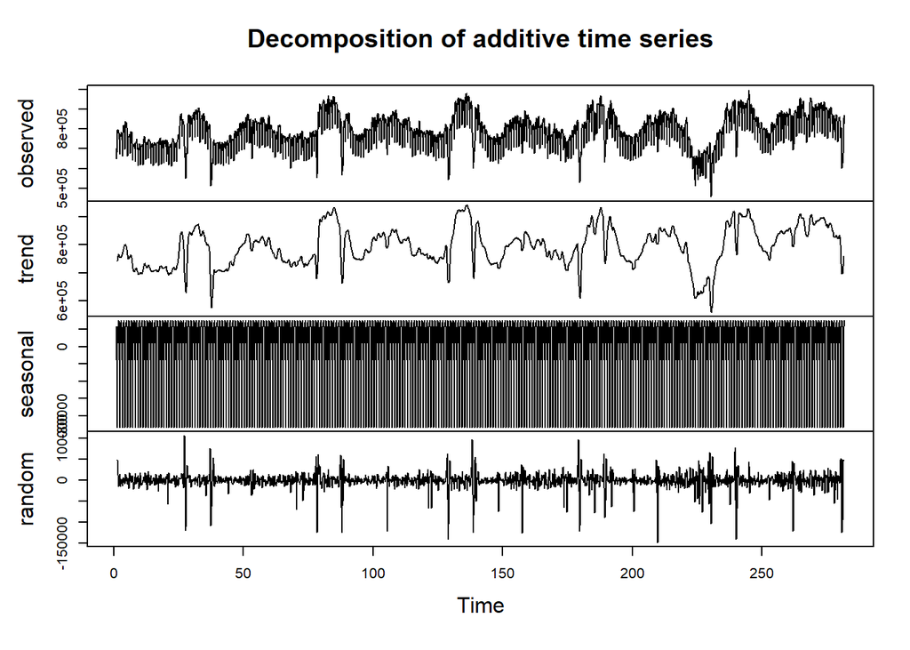

```r
ts_daily = ts(daily_cons$total_cons,freq = 7)
dec_ts_daily = decompose(ts_daily, type="additive")
plot(dec_ts_daily)
```

Our seasonality data is again hard to discuss but now random part of decomposition is much more clear. I can see that it follows 0 mean and constant variance most of time, however most probably because of holidays there are again exceptional values. Now I will take each week. First default week value starts from Sunday, but our data begins with Friday. So I set week_start value to 5 which corresponds to Friday. After I found weekly total electricity consumption values, I plot the all data according to weeks. In the graph, biggest outliers are because of pandemic in March 2020.

```r
daily_cons[,weekdate:=floor_date(daily_cons$Date,"week",week_start = 5)] #our data starts with Friday so we take Friday as first day
daily_cons
```

```
##             Date total_cons   weekdate
##    1: 2016-01-01   648689.2 2016-01-01
##    2: 2016-01-02   702608.5 2016-01-01
##    3: 2016-01-03   685453.1 2016-01-01
##    4: 2016-01-04   794904.7 2016-01-01
##    5: 2016-01-05   796749.9 2016-01-01
##   ---
## 1963: 2021-05-16   677635.7 2021-05-14
## 1964: 2021-05-17   811242.1 2021-05-14
## 1965: 2021-05-18   855112.9 2021-05-14
## 1966: 2021-05-19   829748.2 2021-05-14
## 1967: 2021-05-20   870574.4 2021-05-14
```

```r
weekly_cons = daily_cons[,list(totalweek_cons =sum(total_cons, na.rm=T)), by=list(date(weekdate))]
weekly_cons
```

```
##            date totalweek_cons
##   1: 2016-01-01        5192468
##   2: 2016-01-08        5286483
##   3: 2016-01-15        5419988
##   4: 2016-01-22        5604131
##   5: 2016-01-29        5274281
##  ---
## 277: 2021-04-16        5917766
## 278: 2021-04-23        5786879
## 279: 2021-04-30        5752816
## 280: 2021-05-07        5344122
## 281: 2021-05-14        5322355
```

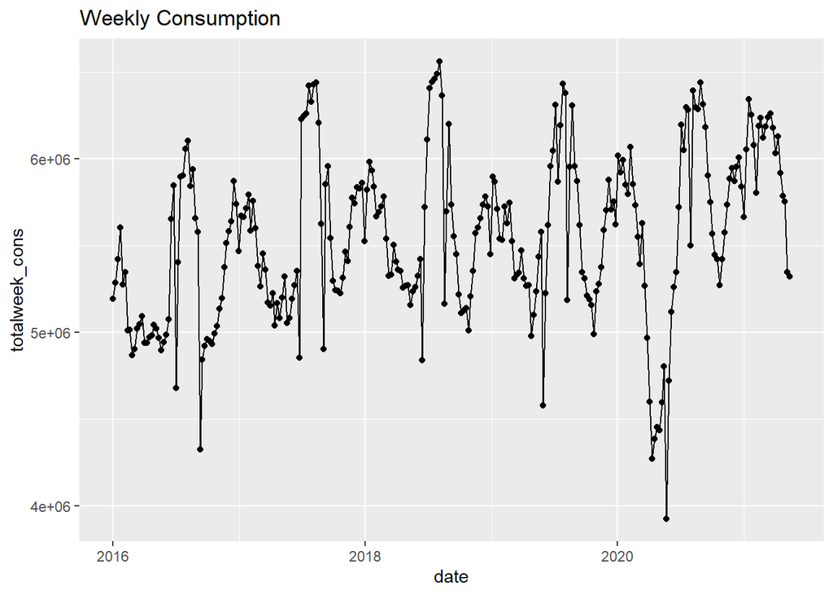

```r
ggplot(weekly_cons, aes(x=date,y=totalweek_cons)) + geom_line() + geom_point() + ggtitle("Weekly Consumption")
```

I create time series with 52 frequency for weekly seasonality. Then I decomposed it.

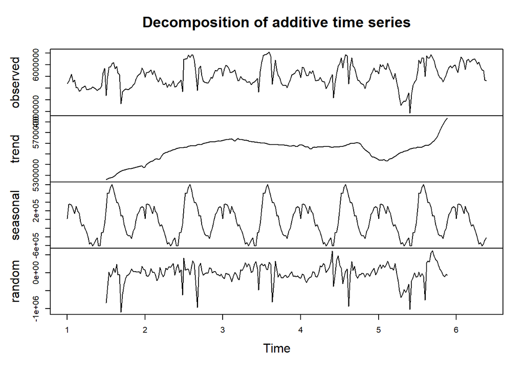

```r
ts_weekly = ts(weekly_cons$totalweek_cons, frequency = 52)
dec_ts_weekly = decompose(ts_weekly, type="additive")
plot(dec_ts_weekly)
```

In this plot it is possible to say that there is a seasonal pattern in decomposition and increasing trend over all data. However in random part, there is no randomness. It has seasonality again and its variance is not constant. I think, since we have less periods our random part of decomposition is now not seems like random. After that point it will be less random in every step. Next seasonality type is monthly seasonality:

```r
daily_cons[,monthdate:=floor_date(daily_cons$Date,"month")]
daily_cons
```

```
##             Date total_cons   weekdate  monthdate
##    1: 2016-01-01   648689.2 2016-01-01 2016-01-01
##    2: 2016-01-02   702608.5 2016-01-01 2016-01-01
##    3: 2016-01-03   685453.1 2016-01-01 2016-01-01
##    4: 2016-01-04   794904.7 2016-01-01 2016-01-01
##    5: 2016-01-05   796749.9 2016-01-01 2016-01-01
##   ---
## 1963: 2021-05-16   677635.7 2021-05-14 2021-05-01
## 1964: 2021-05-17   811242.1 2021-05-14 2021-05-01
## 1965: 2021-05-18   855112.9 2021-05-14 2021-05-01
## 1966: 2021-05-19   829748.2 2021-05-14 2021-05-01
## 1967: 2021-05-20   870574.4 2021-05-14 2021-05-01
```

```r
monthly_cons = daily_cons[,list(totalmonth_cos =sum(total_cons, na.rm=T)), by=list(date(monthdate))]
monthly_cons
```

```
##           date totalmonth_cos
##  1: 2016-01-01       23730799
##  2: 2016-02-01       21153165
##  3: 2016-03-01       22188508
##  4: 2016-04-01       21301824
##  5: 2016-05-01       21900302
##  6: 2016-06-01       23051249
##  7: 2016-07-01       24369823
##  8: 2016-08-01       26268794
##  9: 2016-09-01       21233349
## 10: 2016-10-01       21850083
## 11: 2016-11-01       22683005
## 12: 2016-12-01       25161281
## 13: 2017-01-01       25102545
## 14: 2017-02-01       22451554
```

[output cut: 52 more lines]

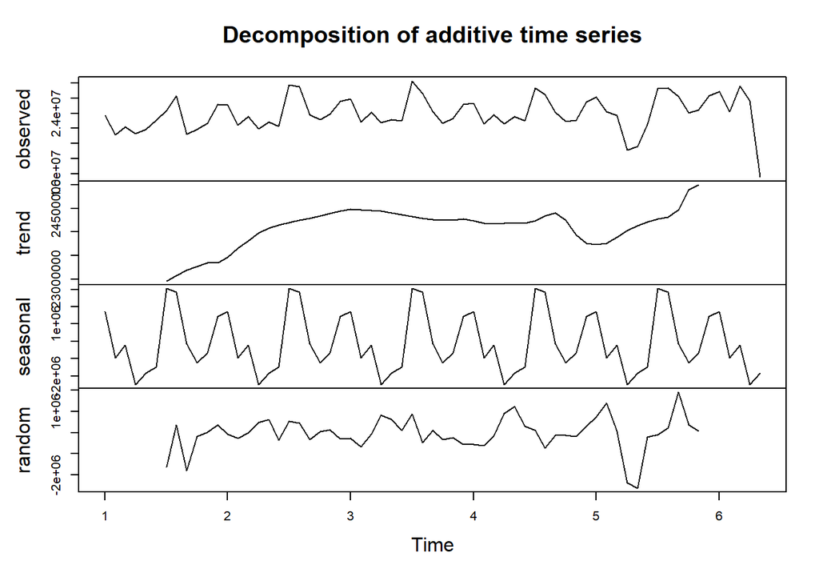

```r
ts_monthly = ts(monthly_cons$totalmonth_cos, frequency = 12)
dec_ts_monthly = decompose(ts_monthly, type="additive")
plot(dec_ts_monthly)
```

There is also monthly seasonalities and in random part there is an outlier after 5. It corresponds to pandemic in March 2020. Last of my seasonality check is quarterly seasonality.

```r
daily_cons[,quarterdate:=floor_date(daily_cons$Date,"quarter")]
daily_cons
```

```
##             Date total_cons   weekdate  monthdate quarterdate
##    1: 2016-01-01   648689.2 2016-01-01 2016-01-01  2016-01-01
##    2: 2016-01-02   702608.5 2016-01-01 2016-01-01  2016-01-01
##    3: 2016-01-03   685453.1 2016-01-01 2016-01-01  2016-01-01
##    4: 2016-01-04   794904.7 2016-01-01 2016-01-01  2016-01-01
##    5: 2016-01-05   796749.9 2016-01-01 2016-01-01  2016-01-01
##   ---
## 1963: 2021-05-16   677635.7 2021-05-14 2021-05-01  2021-04-01
## 1964: 2021-05-17   811242.1 2021-05-14 2021-05-01  2021-04-01
## 1965: 2021-05-18   855112.9 2021-05-14 2021-05-01  2021-04-01
## 1966: 2021-05-19   829748.2 2021-05-14 2021-05-01  2021-04-01
## 1967: 2021-05-20   870574.4 2021-05-14 2021-05-01  2021-04-01
```

```r
quarterly_cons = daily_cons[,list(totalquarter_cos =sum(total_cons, na.rm=T)), by=list(date(quarterdate))]
quarterly_cons
```

```
##           date totalquarter_cos
##  1: 2016-01-01         67072472
##  2: 2016-04-01         66253375
##  3: 2016-07-01         71871967
##  4: 2016-10-01         69694369
##  5: 2017-01-01         71140598
##  6: 2017-04-01         67111045
##  7: 2017-07-01         79106529
##  8: 2017-10-01         72617005
##  9: 2018-01-01         72919037
## 10: 2018-04-01         68986502
## 11: 2018-07-01         79115394
## 12: 2018-10-01         71150419
## 13: 2019-01-01         71793065
## 14: 2019-04-01         69232293
## 15: 2019-07-01         77928043
## 16: 2019-10-01         71493523
## 17: 2020-01-01         74138415
## 18: 2020-04-01         61298295
## 19: 2020-07-01         80821710
## 20: 2020-10-01         74758812
## 21: 2021-01-01         78694598
## 22: 2021-04-01         41193737
##           date totalquarter_cos
```

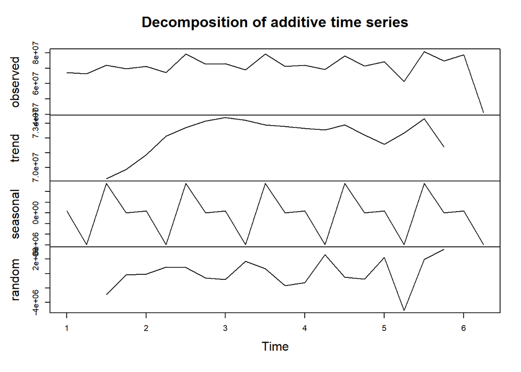

```r
ts_quarterly = ts(quarterly_cons$totalquarter_cos, frequency = 4)
dec_ts_quarterly = decompose(ts_quarterly, type="additive")
plot(dec_ts_quarterly)
```

Seasonality in decomposed quarterly time series can be seen in seasonal part. In each quarter of every year there is some seasonality. Trend is generally increasing except pandemic period. Another effect of pandemic can be seen in random part again.

## Hourly and Daily Decomposition (168 hours)

Since I am going to build my model based on this seasonality and then I will forecast some values, first I will seperate my data to a training set which I will work on it and a test set which I will check my forecasted values on it.  
I found the length of my data and then calculated how many hours are there in 14-days period. I decided to take 46872 of my data to training test and remaining part into test set.

```r
length(elec_consumption$Consumption)
```

```
## [1] 47208
```

```r
14*24
```

```
## [1] 336
```

```r
47208 - 336
```

```
## [1] 46872
```

```r
elec_consumption_tr = head(elec_consumption$Consumption,46872)
elec_consumption_te = tail(elec_consumption$Consumption,336)
```

Now I will prepare a ts and decompose it.

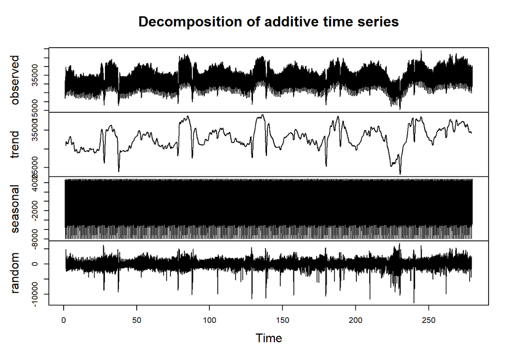

```r
ts_last = ts(elec_consumption_tr, frequency = 168)
last_decomposed = decompose(ts_last, type ="additive")
plot(last_decomposed)
```

Our graphs are very similar to both daily and hourly decomposed ones. In random part it generally fits to assumptions that it follows 0 mean and constant variance. However in some parts it violate this assumption because of holidays most probably. Huge violation occurs in between middle and last parts of the random graph which occurs because of pandemic in my opinion.

### Detrending and Deseasonalization

I have to reach random part of this decomposition to make forecast on it. So I will deseasonalize and detrend my data.Then I will plot it to see whether it is the same with random or not.

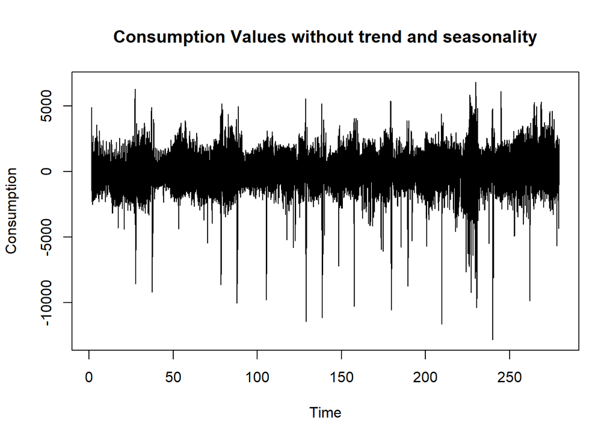

```r
deseasonalized_last = ts_last - last_decomposed$seasonal
detrended_deseasonalized_last = deseasonalized_last - last_decomposed$trend
ts.plot(detrended_deseasonalized_last, xlab = "Time", ylab = "Consumption",main="Consumption Values without trend and seasonality")
```

### Finding Best AR Model

I will try some ar models to my last random data “detrended_deseasonalized_last”. I will start with p=1 and increase it 1 in each step to find better models with lower aic values.

```r
ar_model = arima(detrended_deseasonalized_last, order=c(1,0,0))
ar_model
```

```
##
## Call:
## arima(x = detrended_deseasonalized_last, order = c(1, 0, 0))
##
## Coefficients:
##          ar1  intercept
##       0.9224     0.1337
## s.e.  0.0018    33.7845
##
## sigma^2 estimated as 320753:  log likelihood = -362337.7,  aic = 724681.3
```

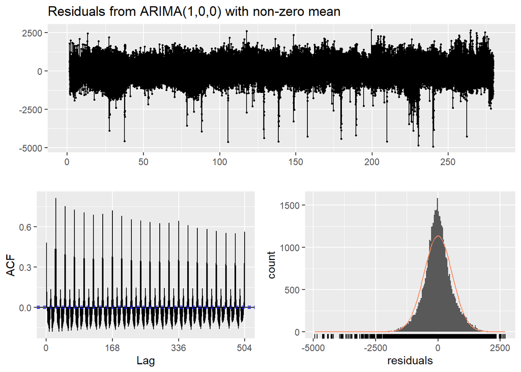

```
##
##  Ljung-Box test
##
## data:  Residuals from ARIMA(1,0,0) with non-zero mean
## Q* = 668121, df = 334, p-value < 2.2e-16
##
## Model df: 2.   Total lags used: 336
```

```r
checkresiduals(ar_model)
```

```r
ar_model2 = arima(detrended_deseasonalized_last, order=c(2,0,0))
ar_model2
```

```
##
## Call:
## arima(x = detrended_deseasonalized_last, order = c(2, 0, 0))
##
## Coefficients:
##         ar1      ar2  intercept
##       1.403  -0.5212     0.1330
## s.e.  0.004   0.0040    18.9274
##
## sigma^2 estimated as 233634:  log likelihood = -354937.4,  aic = 709882.8
```

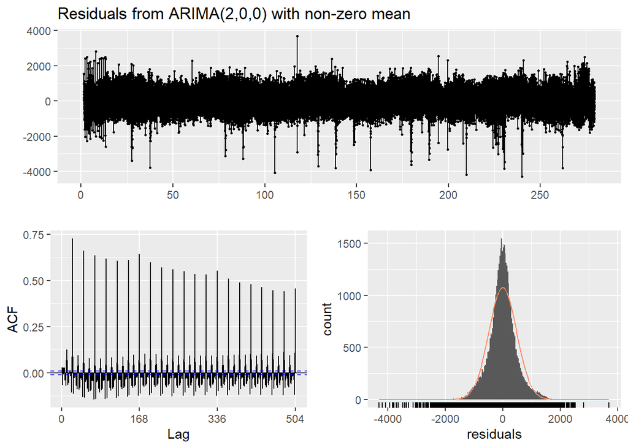

```
##
##  Ljung-Box test
##
## data:  Residuals from ARIMA(2,0,0) with non-zero mean
## Q* = 297302, df = 333, p-value < 2.2e-16
##
## Model df: 3.   Total lags used: 336
```

```r
checkresiduals(ar_model2)
```

```r
ar_model3 = arima(detrended_deseasonalized_last, order=c(3,0,0))
ar_model3
```

```
##
## Call:
## arima(x = detrended_deseasonalized_last, order = c(3, 0, 0))
##
## Coefficients:
##          ar1      ar2     ar3  intercept
##       1.4325  -0.6003  0.0564     0.1329
## s.e.  0.0046   0.0076  0.0046    20.0464
##
## sigma^2 estimated as 232891:  log likelihood = -354863,  aic = 709736
```

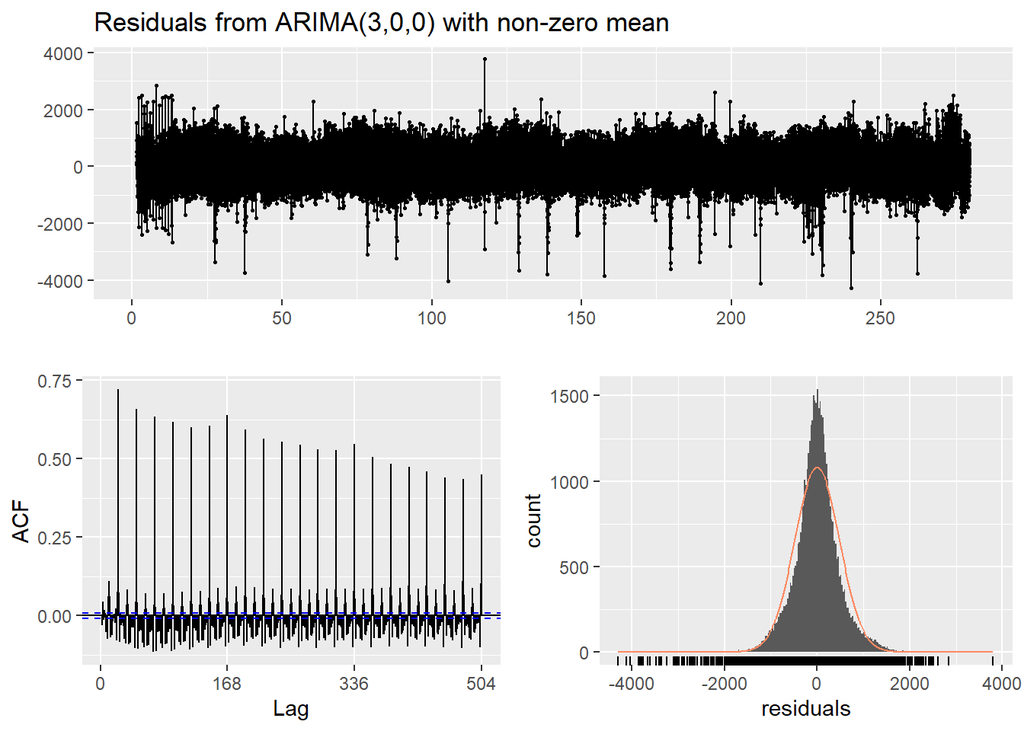

```
##
##  Ljung-Box test
##
## data:  Residuals from ARIMA(3,0,0) with non-zero mean
## Q* = 283741, df = 332, p-value < 2.2e-16
##
## Model df: 4.   Total lags used: 336
```

```r
checkresiduals(ar_model3)
```

```r
ar_model4 = arima(detrended_deseasonalized_last, order=c(4,0,0))
ar_model4
```

```
##
## Call:
## arima(x = detrended_deseasonalized_last, order = c(4, 0, 0))
##
## Coefficients:
##          ar1      ar2     ar3      ar4  intercept
##       1.4356  -0.6344  0.1377  -0.0568     0.1334
## s.e.  0.0046   0.0081  0.0081   0.0046    18.9160
##
## sigma^2 estimated as 232141:  log likelihood = -354787.7,  aic = 709587.4
```

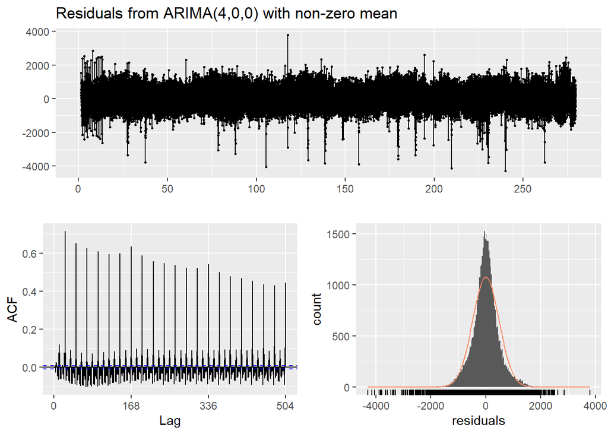

```
##
##  Ljung-Box test
##
## data:  Residuals from ARIMA(4,0,0) with non-zero mean
## Q* = 278601, df = 331, p-value < 2.2e-16
##
## Model df: 5.   Total lags used: 336
```

```r
checkresiduals(ar_model4)
```

```r
ar_model5 = arima(detrended_deseasonalized_last, order=c(5,0,0))
ar_model5
```

```
##
## Call:
## arima(x = detrended_deseasonalized_last, order = c(5, 0, 0))
##
## Coefficients:
##          ar1      ar2     ar3      ar4     ar5  intercept
##       1.4364  -0.6362  0.1460  -0.0757  0.0132     0.1339
## s.e.  0.0046   0.0081  0.0086   0.0081  0.0046    19.1715
##
## sigma^2 estimated as 232101:  log likelihood = -354783.7,  aic = 709581.3
```

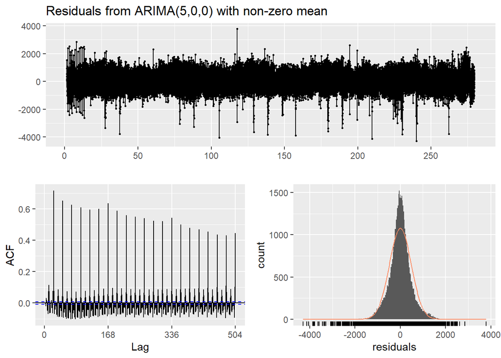

```
##
##  Ljung-Box test
##
## data:  Residuals from ARIMA(5,0,0) with non-zero mean
## Q* = 279250, df = 330, p-value < 2.2e-16
##
## Model df: 6.   Total lags used: 336
```

```r
checkresiduals(ar_model5) # This model has the least aic value and its residuals are more likely to follow normal distribution
```

In general all of the ar models I tried have very huge aic values. Their residuals graph is somehow following normal distribution but there are too many outliers. The lowest aic value is in the ar_model5 in this case. This model is slightly better with 709581.

## Finding Best MA Model

Again starting from q=1 I will try some models to my data.

```r
ma_model = arima(detrended_deseasonalized_last, order = c(0,0,1))
ma_model
```

```
##
## Call:
## arima(x = detrended_deseasonalized_last, order = c(0, 0, 1))
##
## Coefficients:
##          ma1  intercept
##       0.8841     0.1321
## s.e.  0.0015     7.3883
##
## sigma^2 estimated as 718189:  log likelihood = -381160.6,  aic = 762327.2
```

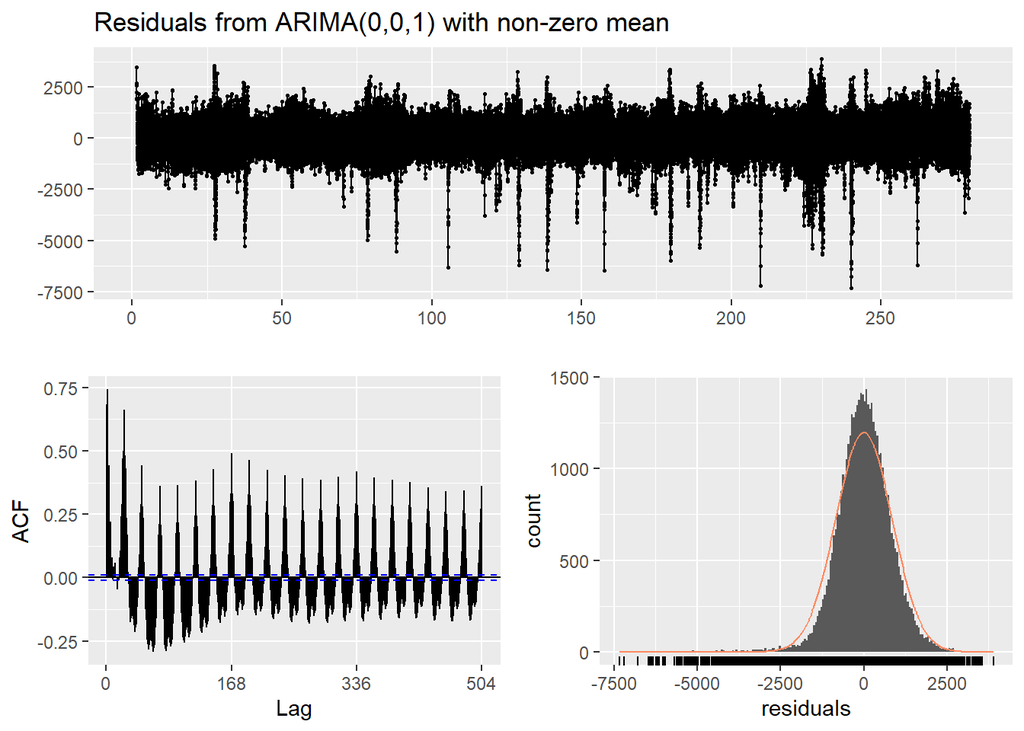

```
##
##  Ljung-Box test
##
## data:  Residuals from ARIMA(0,0,1) with non-zero mean
## Q* = 646044, df = 334, p-value < 2.2e-16
##
## Model df: 2.   Total lags used: 336
```

```r
checkresiduals(ma_model)
```

```r
ma_model2 = arima(detrended_deseasonalized_last, order = c(0,0,2))
ma_model2
```

```
##
## Call:
## arima(x = detrended_deseasonalized_last, order = c(0, 0, 2))
##
## Coefficients:
##          ma1     ma2  intercept
##       1.2859  0.6526     0.1324
## s.e.  0.0033  0.0029     8.6722
##
## sigma^2 estimated as 406748:  log likelihood = -367884.3,  aic = 735776.7
```

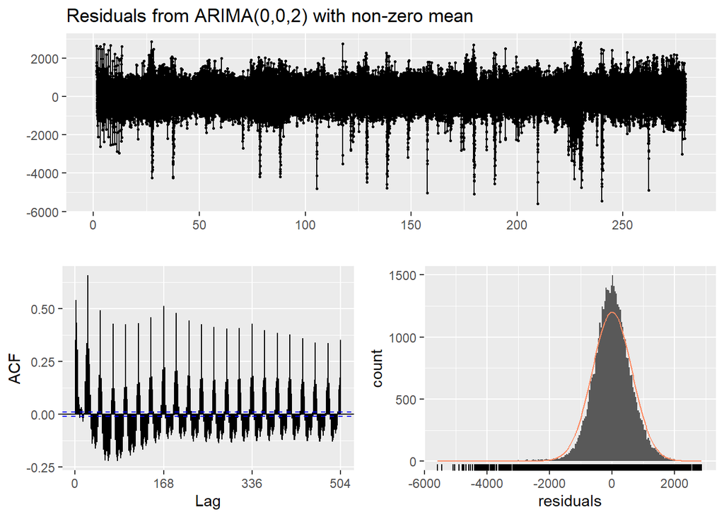

```
##
##  Ljung-Box test
##
## data:  Residuals from ARIMA(0,0,2) with non-zero mean
## Q* = 402575, df = 333, p-value < 2.2e-16
##
## Model df: 3.   Total lags used: 336
```

```r
checkresiduals(ma_model2)
```

```r
ma_model3 = arima(detrended_deseasonalized_last, order = c(0,0,3))
ma_model3
```

```
##
## Call:
## arima(x = detrended_deseasonalized_last, order = c(0, 0, 3))
##
## Coefficients:
##          ma1     ma2     ma3  intercept
##       1.3855  1.0886  0.5062     0.1331
## s.e.  0.0040  0.0047  0.0035    10.1396
##
## sigma^2 estimated as 303110:  log likelihood = -361016.7,  aic = 722043.4
```

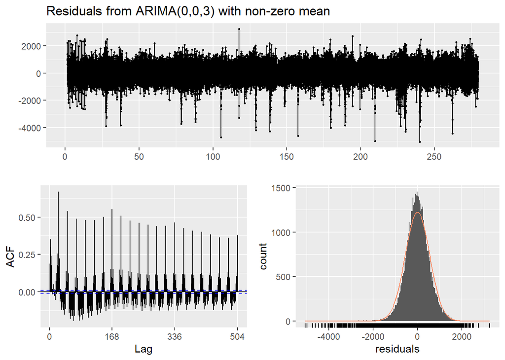

```
##
##  Ljung-Box test
##
## data:  Residuals from ARIMA(0,0,3) with non-zero mean
## Q* = 301297, df = 332, p-value < 2.2e-16
##
## Model df: 4.   Total lags used: 336
```

```r
checkresiduals(ma_model3)
```

```r
ma_model4 = arima(detrended_deseasonalized_last, order = c(0,0,4))
ma_model4
```

```
##
## Call:
## arima(x = detrended_deseasonalized_last, order = c(0, 0, 4))
##
## Coefficients:
##          ma1     ma2     ma3     ma4  intercept
##       1.4358  1.2809  0.8440  0.3220     0.1332
## s.e.  0.0047  0.0069  0.0055  0.0037    11.6633
##
## sigma^2 estimated as 266535:  log likelihood = -358013.9,  aic = 716039.8
```

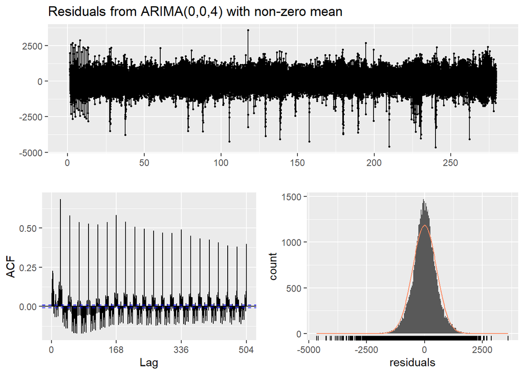

```
##
##  Ljung-Box test
##
## data:  Residuals from ARIMA(0,0,4) with non-zero mean
## Q* = 274765, df = 331, p-value < 2.2e-16
##
## Model df: 5.   Total lags used: 336
```

```r
checkresiduals(ma_model4)
```

```r
ma_model5 = arima(detrended_deseasonalized_last, order = c(0,0,5))
ma_model5
```

```
##
## Call:
## arima(x = detrended_deseasonalized_last, order = c(0, 0, 5))
##
## Coefficients:
##          ma1     ma2     ma3     ma4     ma5  intercept
##       1.4397  1.3704  1.1031  0.6799  0.2671     0.1345
## s.e.  0.0045  0.0072  0.0076  0.0064  0.0040    13.4477
##
## sigma^2 estimated as 245910:  log likelihood = -356133.2,  aic = 712280.4
```

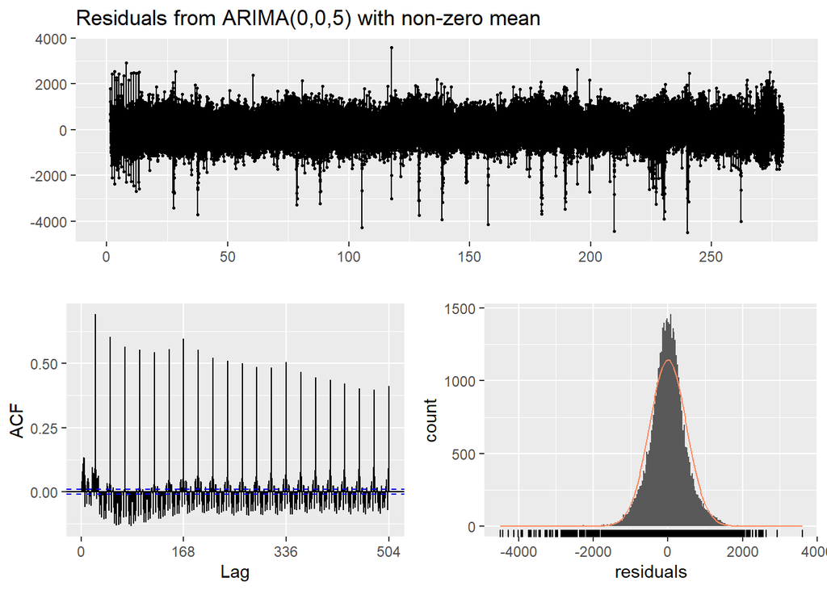

```
##
##  Ljung-Box test
##
## data:  Residuals from ARIMA(0,0,5) with non-zero mean
## Q* = 250658, df = 330, p-value < 2.2e-16
##
## Model df: 6.   Total lags used: 336
```

```r
checkresiduals(ma_model5)  # This model has the least aic value and its residuals are more likely to follow normal distribution
```

These models are almost same with AR models. They again have too high aic values. The lowest aic value is 712280.4 which is in ma_model5.

## Trying AR-MA Models

```r
arima1 = arima(detrended_deseasonalized_last, order = c(5,0,5))
arima1
```

```
##
## Call:
## arima(x = detrended_deseasonalized_last, order = c(5, 0, 5))
##
## Coefficients:
```

```
##          ar1     ar2     ar3      ar4     ar5     ma1     ma2     ma3      ma4
##       0.5741  0.1757  0.1808  -0.0622  -0.123  0.8633  0.4257  0.0328  -0.1354
## s.e.     NaN  0.0528     NaN      NaN     NaN     NaN     NaN     NaN      NaN
##           ma5  intercept
##       -0.0448     0.1952
## s.e.      NaN    18.7394
##
## sigma^2 estimated as 231785:  log likelihood = -354751.8,  aic = 709527.6
```

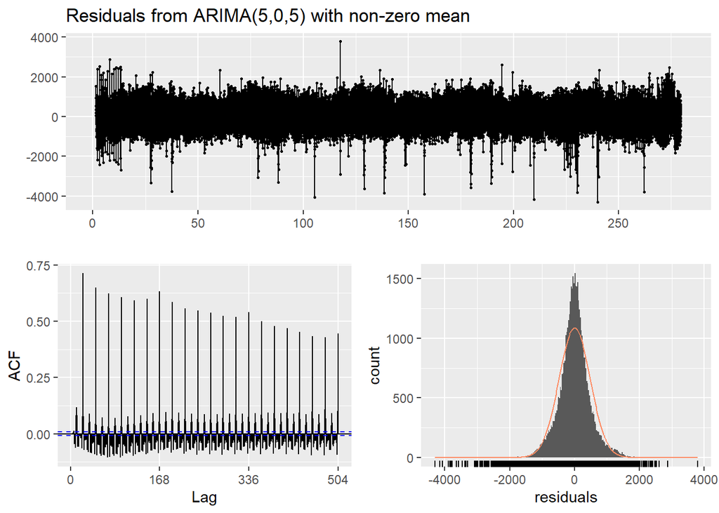

```
##
##  Ljung-Box test
##
## data:  Residuals from ARIMA(5,0,5) with non-zero mean
## Q* = 278584, df = 325, p-value < 2.2e-16
##
## Model df: 11.   Total lags used: 336
```

```r
checkresiduals(arima1)
```

```r
arima2 = arima(detrended_deseasonalized_last, order = c(4,0,5))
arima2
```

```
##
## Call:
## arima(x = detrended_deseasonalized_last, order = c(4, 0, 5))
##
## Coefficients:
```

```
##          ar1     ar2      ar3      ar4     ma1     ma2      ma3      ma4
##       0.7274  0.2463  -0.0024  -0.1688  0.7100  0.1348  -0.1035  -0.0605
## s.e.  0.1648  0.1323      NaN   0.0449  0.1647  0.0847   0.0314   0.0133
##           ma5  intercept
##       -0.0073     0.3086
## s.e.   0.0071    18.8845
##
## sigma^2 estimated as 231848:  log likelihood = -354758.2,  aic = 709538.4
```

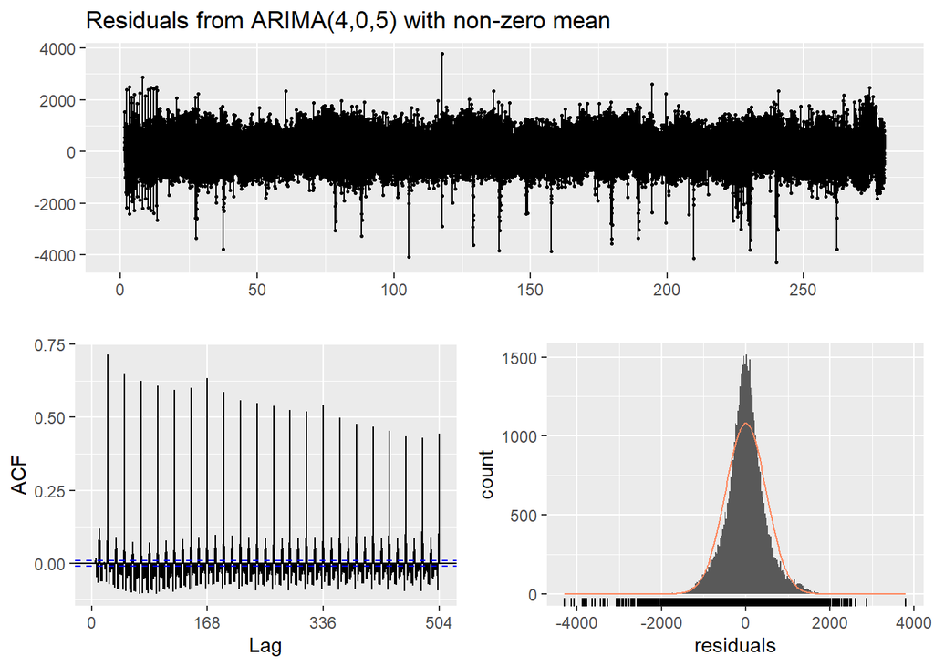

```
##
##  Ljung-Box test
##
## data:  Residuals from ARIMA(4,0,5) with non-zero mean
## Q* = 278568, df = 326, p-value < 2.2e-16
##
## Model df: 10.   Total lags used: 336
```

```r
checkresiduals(arima2)
```

```r
arima3 = arima(detrended_deseasonalized_last, order = c(5,0,4))
arima3
```

```
##
## Call:
## arima(x = detrended_deseasonalized_last, order = c(5, 0, 4))
##
## Coefficients:
```

```
##          ar1     ar2     ar3      ar4      ar5     ma1     ma2     ma3     ma4
##       0.0512  0.5916  0.1288  -0.0275  -0.1334  1.3878  0.7634  0.2395  -0.011
## s.e.     NaN     NaN     NaN      NaN      NaN     NaN     NaN     NaN     NaN
##       intercept
##          0.1465
## s.e.    19.3386
##
## sigma^2 estimated as 231655:  log likelihood = -354738.8,  aic = 709499.6
```

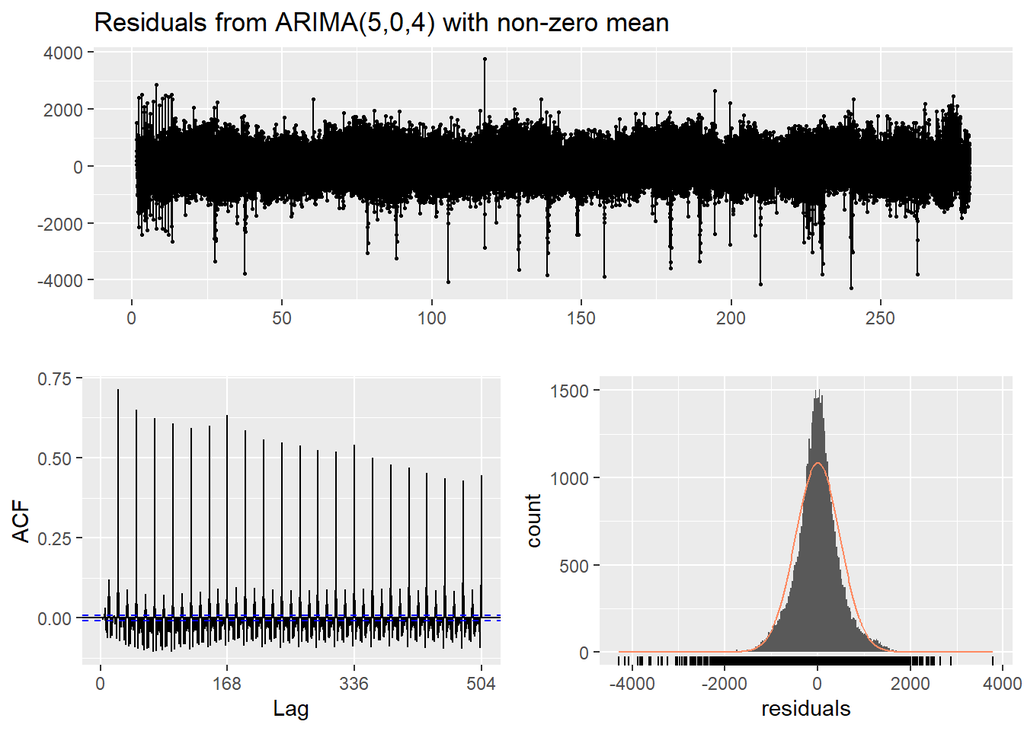

```
##
##  Ljung-Box test
##
## data:  Residuals from ARIMA(5,0,4) with non-zero mean
## Q* = 278220, df = 326, p-value < 2.2e-16
##
## Model df: 10.   Total lags used: 336
```

```r
checkresiduals(arima3)
```

```r
arima4 = arima(detrended_deseasonalized_last, order = c(3,0,5)) #Has the lowest AIC value.
arima4
```

```
##
## Call:
## arima(x = detrended_deseasonalized_last, order = c(3, 0, 5))
##
## Coefficients:
##          ar1     ar2      ar3     ma1      ma2      ma3      ma4      ma5
##       0.6851  0.5997  -0.4593  0.7534  -0.1581  -0.0943  -0.0210  -0.0003
## s.e.  0.0300  0.0316   0.0197  0.0304   0.0345   0.0212   0.0133   0.0074
##       intercept
##          0.4376
## s.e.    18.8912
##
## sigma^2 estimated as 231573:  log likelihood = -354730.5,  aic = 709481.1
```

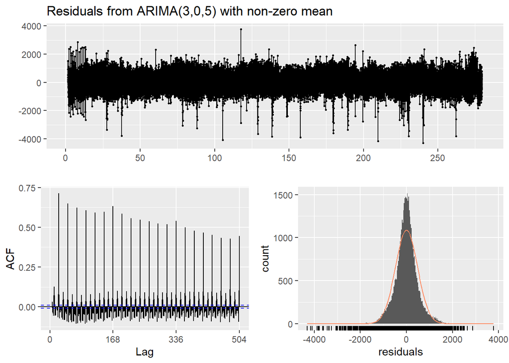

```
##
##  Ljung-Box test
##
## data:  Residuals from ARIMA(3,0,5) with non-zero mean
## Q* = 277266, df = 327, p-value < 2.2e-16
##
## Model df: 9.   Total lags used: 336
```

```r
checkresiduals(arima4)
```

```r
arima5 = arima(detrended_deseasonalized_last, order = c(5,0,3))
arima5
```

```
##
## Call:
## arima(x = detrended_deseasonalized_last, order = c(5, 0, 3))
##
## Coefficients:
##          ar1     ar2     ar3      ar4      ar5     ma1     ma2     ma3
##       0.1452  0.5783  0.0348  -0.0088  -0.1111  1.2943  0.6442  0.2188
## s.e.  0.1551  0.1022  0.1245   0.0535   0.0349  0.1555  0.1924  0.0783
##       intercept
##          0.3486
## s.e.    19.4439
##
## sigma^2 estimated as 231667:  log likelihood = -354739.9,  aic = 709499.9
```

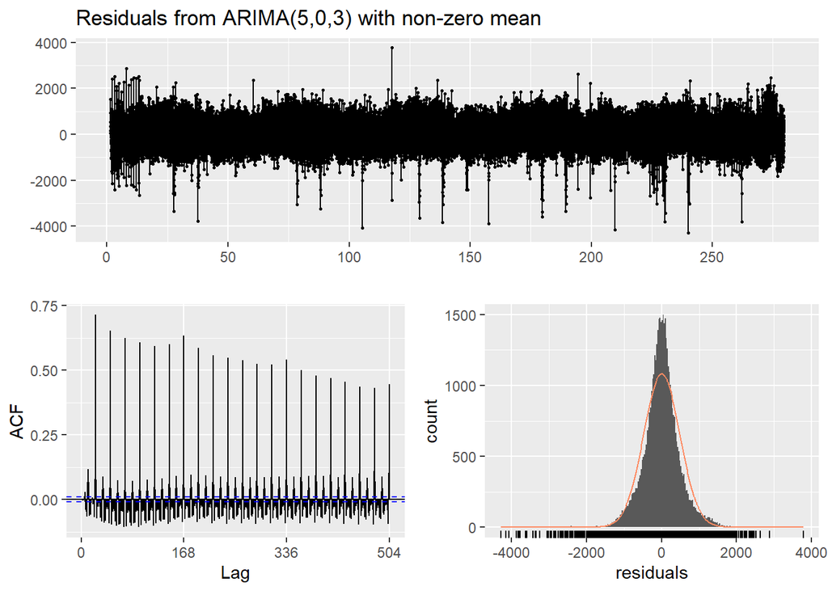

```
##
##  Ljung-Box test
##
## data:  Residuals from ARIMA(5,0,3) with non-zero mean
## Q* = 278501, df = 327, p-value < 2.2e-16
##
## Model df: 9.   Total lags used: 336
```

```r
checkresiduals(arima5)
```

## Fitted Model Before Forecast

I will add my seasonal and trend values to fit my model on actual values. Then I looked last values of my fitted model to see how many NA’s I have. After c(279,84) there are 84 NA’s. This means that I need to forecast 84 more periods before 14 days. Then my forecasted ts model will start from c(279,85).

```r
last_fitted = detrended_deseasonalized_last - residuals(arima4)
last_fitted_transformed = last_fitted + last_decomposed$seasonal + last_decomposed$trend
tail(last_fitted_transformed,90)
```

```
## Time Series:
## Start = c(279, 79)
## End = c(279, 168)
## Frequency = 168
##  [1] 27360.66 27937.91 33373.98 35983.53 37245.86 39120.76       NA       NA
##  [9]       NA       NA       NA       NA       NA       NA       NA       NA
## [17]       NA       NA       NA       NA       NA       NA       NA       NA
## [25]       NA       NA       NA       NA       NA       NA       NA       NA
## [33]       NA       NA       NA       NA       NA       NA       NA       NA
## [41]       NA       NA       NA       NA       NA       NA       NA       NA
## [49]       NA       NA       NA       NA       NA       NA       NA       NA
## [57]       NA       NA       NA       NA       NA       NA       NA       NA
## [65]       NA       NA       NA       NA       NA       NA       NA       NA
## [73]       NA       NA       NA       NA       NA       NA       NA       NA
## [81]       NA       NA       NA       NA       NA       NA       NA       NA
## [89]       NA       NA
```

I forecast 336+84 periods with predict() function. Then I will build ts model with freq 168 and it will start from c(279,85) which is the one point later than fitted model. I will plot actual values with black, fitted values with red. We can see that our fitted model really fits to actual values.To see more detailed, I used last little part of data. If I would use all of the data, I cannot see what is going on.

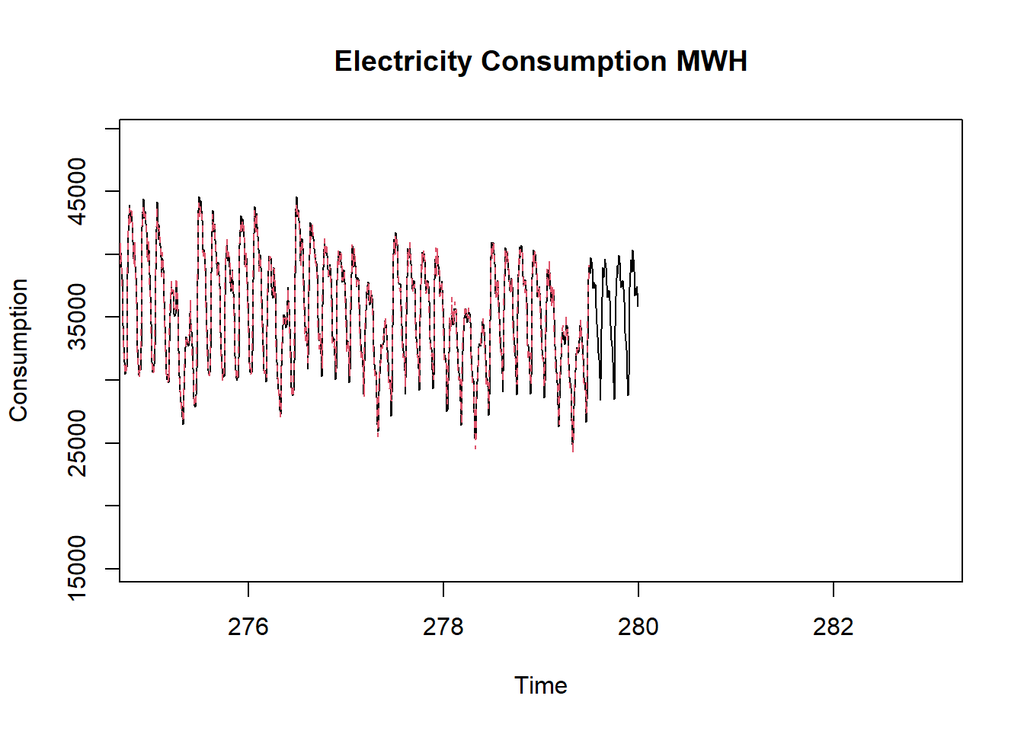

```r
forecast_last = predict(arima4, n.ahead = 336+84)$pred
forecast_last_ts = ts(forecast_last,frequency = 168, start=c(279,85))
plot(ts_last, ylab = "Consumption",main="Electricity Consumption MWH",xlim=c(275,283))
points(last_fitted_transformed, type = "l", col = 2, lty = 2, xlim=c(275,283))
```

Our forecast values are not including trend and seasonality. To evaluate our forecasted values we need to fit them to real model. So I will add “last_trend” for trend part and beginning from 1st seasonality I will add 420 seasonality points as seasonal part “for_seasonality”. “forecast_last2” is my last forecasted model. Then I plot again actual values with black, fitted values with red and forecasted values with green in a graph. In this plot we can see that our forecasted values a little bit less than actual values. Reasons of this can be that we used an assumed trend value (we assume the last trend value is our trend value for all our forecasted periods) and Our arima model is not the best model to use in forecasting.

```r
last_trend = tail(last_decomposed$trend[!is.na(last_decomposed$trend)],1)
tail(last_decomposed$seasonal,1)
```

```
## Time Series:
## Start = c(279, 168)
## End = c(279, 168)
## Frequency = 168
## [1] 1084.808
```

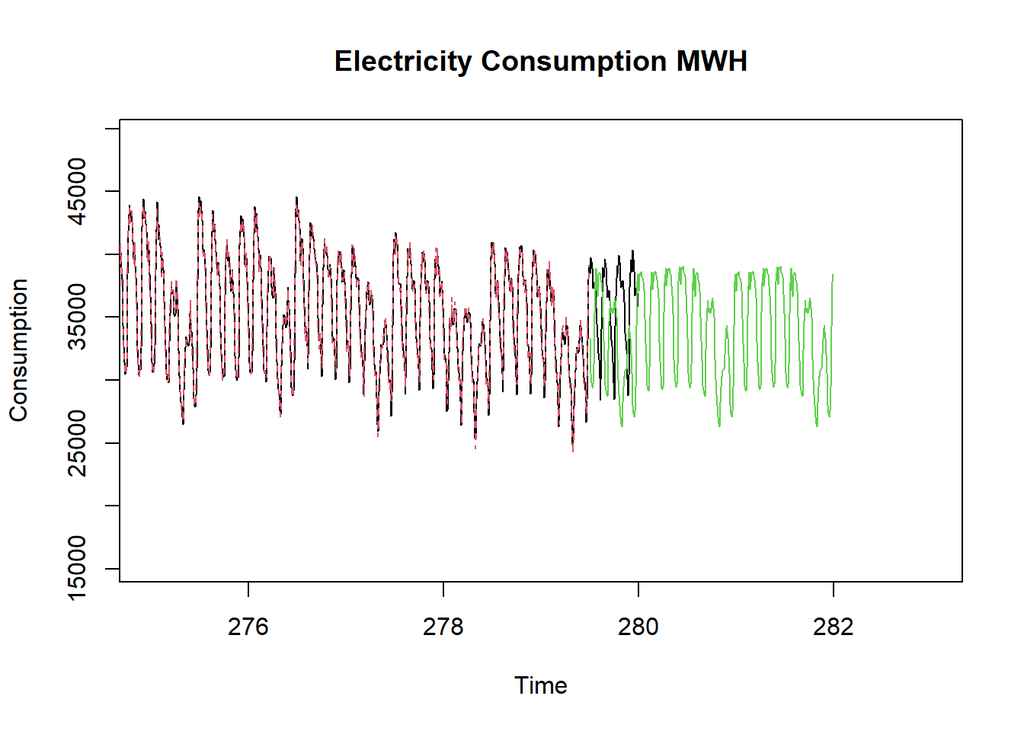

```r
for_seasonality = last_decomposed$seasonal[1:420]
forecast_last2 = forecast_last_ts + last_trend + for_seasonality
plot(ts_last, ylab = "Consumption",main="Electricity Consumption MWH",xlim=c(275,283))
points(last_fitted_transformed, type = "l", col = 2, lty = 2, xlim=c(275,283))
points(forecast_last2, type = "l", col = 3)
```

## Errors in Forecasting

Tail of my forecast_last2 belongs to 14 days period which should be forecasted. Then I take last 336 values of my forecasts and say it to “fourteen_days_forecast” Then I will create “my_table” for see the date-hour and corresponding actual consumption values and forecasted consumption values. I used previous “elec_consumption_te” test set for actual values.

```r
fourteen_days_forecast = tail(forecast_last2,336)

my_table = data.table(forecasted_consumption=fourteen_days_forecast)
my_table = my_table[,actual_consumption:=elec_consumption_te]
datefor = seq(from = as.Date("2017-05-07"), to = as.Date("2017-05-20"), by = 'day')
hourfor = seq(from = 0, to = 23)
my_table = my_table[,forecasted_date:=rep(datefor,each=24)]
my_table = my_table[,forecasted_hours:=rep(hourfor,14)]
my_table = my_table[,forecasteddatewhour:=ymd(forecasted_date)+dhours(forecasted_hours)]
my_table
```

[output not shown]

To evaluate daily forecast and calculate daily bias and mape, I prepare a table “daily_table” which includes total values of everyday in both actual and forecasted consumptions.

```r
daily_table = my_table[,list(daily_total_actual = sum(actual_consumption,na.rm=T)),by=list(forecasted_date)]
a = my_table[,list(daily_total_forecasted = sum(forecasted_consumption,na.rm=T)),by=list(forecasted_date)]
daily_table[,daily_total_forecasted:=a$daily_total_forecasted]
daily_table
```

```
##     forecasted_date daily_total_actual daily_total_forecasted
##  1:      2017-05-07           845958.9               843877.5
##  2:      2017-05-08           827046.6               847098.5
##  3:      2017-05-09           755010.7               851594.8
##  4:      2017-05-10           802693.0               852122.2
##  5:      2017-05-11           806919.3               830152.6
##  6:      2017-05-12           704211.8               767455.7
##  7:      2017-05-13           602281.6               760541.7
##  8:      2017-05-14           625452.9               843877.5
##  9:      2017-05-15           652588.9               847098.5
## 10:      2017-05-16           677635.7               851594.8
## 11:      2017-05-17           811242.1               852122.2
## 12:      2017-05-18           855112.9               830152.6
## 13:      2017-05-19           829748.2               767455.7
## 14:      2017-05-20           870574.4               760541.7
```

I give the daily bias and mape formulas and prepare “daily_bias” and “mape” columns to “daily_table”.

```r
daily_table = daily_table[,daily_bias:=(as.numeric(daily_table$daily_total_actual)-as.numeric(daily_table$daily_total_forecasted))/24]
daily_table = daily_table[,mape:=abs(as.numeric(daily_total_actual)-as.numeric(daily_total_forecasted))/as.numeric(daily_total_actual)/24 * 100]
daily_table
```

[output not shown]

My daily bias is negative and too far from 0 in Ramadan Holidays. Because actual values are abnormally low in religious holidays. Our forecasted models are not considering this holiday effect. Again in the mape values our values are very good in normal days. However mape values are also increasing in Ramadan Holidays.

```r
WMAPE = sum(abs(as.numeric(daily_table$daily_total_actual)-as.numeric(daily_table$daily_total_forecasted))/ as.numeric(daily_table$daily_total_actual))* 100 * as.numeric(daily_table$daily_total_actual)/ sum(as.numeric(daily_table$daily_total_actual))
WMAPE
```

```
##  [1] 14.13800 13.82193 12.61803 13.41492 13.48555 11.76906 10.06557 10.45281
##  [9] 10.90632 11.32491 13.55780 14.29098 13.86708 14.54938
```

```r
avg_WMAPE = sum(WMAPE)/14
avg_WMAPE
```

```
## [1] 12.73302
```

Last I calculated WMAPE for my daily data. My WMAPE values are now high in normal days and it is slightly low in Ramadan Holidays. My average WMAPE value is 12.73 which is not very good value. My model should be developed for better forecast values.

## References

1- [Hourly Electricity Consumption Values from EPİAŞ](https://seffaflik.epias.com.tr/transparency/tuketim/gerceklesen-tuketim/gercek-zamanli-tuketim.xhtml)

2- [MAPE Formula](https://vedexcel.com/how-to-calculate-mape-in-python/)

3- [WMAPE Formula](https://ibf.org/knowledge/glossary/weighted-mean-absolute-percentage-error-wmape-299)